```r
# Load packages
library(dplyr)
library(ggplot2)
library(GGally) # pairplots
library(ggpubr)
library(corrplot) # correlation heatmap
library(e1071) # measure skewness
library(caTools) # split data into training and validation sets
library(randomForest) # random forest model
library(gbm)
theme_set(theme_classic())

# Read data
train <- read.csv('train.csv', stringsAsFactors = FALSE)
test <- read.csv('test.csv', stringsAsFactors = FALSE)
combined_noNA <- rbind(train[-81], test)
```

```r
print(paste("There are", sum(colSums(is.na(combined_noNA)) != 0),
            "variables with at least 1 missing value."))
```

```
## [1] "There are 34 variables with at least 1 missing value."
```

```r
cbind('Missing' = sort(colSums(is.na(combined_noNA)), decreasing = TRUE)[1:34],
      'Proportion' = round(sort(colSums(is.na(combined_noNA)),
                                decreasing = TRUE)[1:34]/nrow(combined_noNA), 3))
```

```
##              Missing Proportion
## PoolQC          2909      0.997
## MiscFeature     2814      0.964
## Alley           2721      0.932
## Fence           2348      0.804
## FireplaceQu     1420      0.486
## LotFrontage      486      0.166
## GarageYrBlt      159      0.054
## GarageFinish     159      0.054
## GarageQual       159      0.054
## GarageCond       159      0.054
## GarageType       157      0.054
## BsmtCond          82      0.028
## BsmtExposure      82      0.028
## BsmtQual          81      0.028
## BsmtFinType2      80      0.027
## BsmtFinType1      79      0.027
## MasVnrType        24      0.008
## MasVnrArea        23      0.008
## MSZoning           4      0.001
## Utilities          2      0.001
## BsmtFullBath       2      0.001
## BsmtHalfBath       2      0.001
## Functional         2      0.001
## Exterior1st        1      0.000
## Exterior2nd        1      0.000
## BsmtFinSF1         1      0.000
## BsmtFinSF2         1      0.000
## BsmtUnfSF          1      0.000
## TotalBsmtSF        1      0.000
## Electrical         1      0.000
## KitchenQual        1      0.000
## GarageCars         1      0.000
## GarageArea         1      0.000
## SaleType           1      0.000
```

```r
combined_noNA <- combined_noNA %>% select(-PoolQC, -PoolArea, -MiscFeature, -MiscVal, -Alley)
```

The next variable, Fence, has missing values in about 80% of the observations. According to the data description, a missing value in this column indicates that the house does not have a fence. Therefore, the missing values were replaced with a string, None, to indicate this.

```r
combined_noNA[which(is.na(combined_noNA$Fence)),'Fence'] <- 'None'
table(combined_noNA$Fence)
```

```
##
## GdPrv  GdWo MnPrv  MnWw  None
##   118   112   329    12  2348
```

The variable FireplaceQu has 1420 missing values. This corresponds to the number of houses without a fireplace. Therefore, the missing values in FireplaceQu were replaced with None. The next variable, LotFrontage, is a numeric variable, so zeros were inserted in place of the missing values. The addition of zeros into this column does affect the skewness of the distribution, which will be addressed later on.

```r
table('Fireplaces' = combined_noNA$Fireplaces)
```

```
## Fireplaces
##    0    1    2    3    4
## 1420 1268  219   11    1
```

```r
combined_noNA[which(is.na(combined_noNA$FireplaceQu)), 'FireplaceQu'] <- 'None'
table('FireplaceQu' = combined_noNA$FireplaceQu)
```

```
## FireplaceQu
##   Ex   Fa   Gd None   Po   TA
##   43   74  744 1420   46  592
```

```r
combined_noNA[which(is.na(combined_noNA$LotFrontage)), 'LotFrontage'] <- 0
```

```r
combined_noNA %>% select(starts_with("Garage")) %>% head()
```

```
##   GarageType GarageYrBlt GarageFinish GarageCars GarageArea GarageQual
## 1     Attchd        2003          RFn          2        548         TA
## 2     Attchd        1976          RFn          2        460         TA
## 3     Attchd        2001          RFn          2        608         TA
## 4     Detchd        1998          Unf          3        642         TA
## 5     Attchd        2000          RFn          3        836         TA
## 6     Attchd        1993          Unf          2        480         TA
##   GarageCond
## 1         TA
## 2         TA
## 3         TA
## 4         TA
## 5         TA
## 6         TA
```

```r
combined_noNA[which(is.na(combined_noNA$GarageType)), "GarageType"] <- "None"
combined_noNA[which(is.na(combined_noNA$GarageFinish)), "GarageFinish"] <- "None"
combined_noNA[which(is.na(combined_noNA$GarageQual)), "GarageQual"] <- "None"
combined_noNA[which(is.na(combined_noNA$GarageCond)), "GarageCond"] <- "None"
combined_noNA$GarageYrBlt <- NULL
```

The next 5 variables relate to the basement. Since they are all categorical variables, the missing values were replaced with None, similar to the other categorical variables above. Missing values in MasVnrType were replaced with None and those in MasVnrAreaby by zero. In categorical variables with a small number of missing values, they would be replaced with the most frequently occurring value. For instance, there is only 1 missing value in Electrical, so it was replaced with SBrkr, the most frequent value in this category. The variable Utilities was dropped from the dataset since only 1 observation has a different level from the rest. Since Exterior1st and Exterior2nd have multiple levels, some of which have only a few observations, those with less than 30 were combined to Other.

```r
combined_noNA[which(is.na(combined_noNA$BsmtQual)), "BsmtQual"] <- "None"
combined_noNA[which(is.na(combined_noNA$BsmtCond)), "BsmtCond"] <- "None"
combined_noNA[which(is.na(combined_noNA$BsmtExposure)), "BsmtExposure"] <- "None"
combined_noNA[which(is.na(combined_noNA$BsmtFinType1)), "BsmtFinType1"] <- "None"
combined_noNA[which(is.na(combined_noNA$BsmtFinType2)), "BsmtFinType2"] <- "None"
combined_noNA[which(is.na(combined_noNA$MasVnrType)), "MasVnrType"] <- "None"
combined_noNA[which(is.na(combined_noNA$MasVnrArea)), "MasVnrArea"] <- 0
table("MSZoning" = combined_noNA$MSZoning)
```

```
## MSZoning
## C (all)      FV      RH      RL      RM
##      25     139      26    2265     460
```

```r
combined_noNA[which(is.na(combined_noNA$MSZoning)), "MSZoning"] <- "RL"
table("Utilities" = combined_noNA$Utilities)
```

```
## Utilities
## AllPub NoSeWa
##   2916      1
```

```r
combined_noNA$Utilities <- NULL
combined_noNA[which(is.na(combined_noNA$BsmtFullBath)), "BsmtFullBath"] <- 0
combined_noNA[which(is.na(combined_noNA$BsmtHalfBath)), "BsmtHalfBath"] <- 0
combined_noNA[which(is.na(combined_noNA$BsmtFinSF1)), "BsmtFinSF1"] <- 0
combined_noNA[which(is.na(combined_noNA$BsmtFinSF2)), "BsmtFinSF2"] <- 0
combined_noNA[which(is.na(combined_noNA$BsmtUnfSF)), "BsmtUnfSF"] <- 0
combined_noNA[which(is.na(combined_noNA$TotalBsmtSF)), "TotalBsmtSF"] <- 0
table("Functional" = combined_noNA$Functional)
```

```
## Functional
## Maj1 Maj2 Min1 Min2  Mod  Sev  Typ
##   19    9   65   70   35    2 2717
```

```r
combined_noNA[which(is.na(combined_noNA$Functional)), "Functional"] <- "Typ"
table("Exterior1st" = combined_noNA$Exterior1st)
```

```
## Exterior1st
## AsbShng AsphShn BrkComm BrkFace  CBlock CemntBd HdBoard ImStucc MetalSd
##      44       2       6      87       2     126     442       1     450
## Plywood   Stone  Stucco VinylSd Wd Sdng WdShing
##     221       2      43    1025     411      56
```

```r
combined_noNA[which(is.na(combined_noNA$Exterior1st)), "Exterior1st"] <- "Other"
combined_noNA[combined_noNA$Exterior1st %in% c("AsphShn", "BrkComm", "CBlock", "ImStucc", "Stone"), "Exterior1st"] <- "Other"
table("Exterior1st" = combined_noNA$Exterior2nd)
```

```
## Exterior1st
## AsbShng AsphShn Brk Cmn BrkFace  CBlock CmentBd HdBoard ImStucc MetalSd
##      38       4      22      47       3     126     406      15     447
##   Other Plywood   Stone  Stucco VinylSd Wd Sdng Wd Shng
##       1     270       6      47    1014     391      81
```

```r
combined_noNA[which(is.na(combined_noNA$Exterior2nd)), "Exterior2nd"] <- "Other"
combined_noNA[combined_noNA$Exterior2nd %in% c("AsphShn", "BrkComm", "CBlock", "ImStucc", "Stone"), "Exterior2nd"] <- "Other"
table("KitchenQual" = combined_noNA$KitchenQual)
```

```
## KitchenQual
##   Ex   Fa   Gd   TA
##  205   70 1151 1492
```

```r
combined_noNA[which(is.na(combined_noNA$KitchenQual)), "KitchenQual"] <- "TA"
table("Electrical" = combined_noNA$Electrical)
```

```
## Electrical
## FuseA FuseF FuseP   Mix SBrkr
##   188    50     8     1  2671
```

```r
combined_noNA[which(is.na(combined_noNA$Electrical)), "Electrical"] <- "SBrkr"
table("SaleType" = combined_noNA$SaleType)
```

```
## SaleType
##   COD   Con ConLD ConLI ConLw   CWD   New   Oth    WD
##    87     5    26     9     8    12   239     7  2525
```

```r
combined_noNA[which(is.na(combined_noNA$SaleType)), "SaleType"] <- "WD"
combined_noNA[which(is.na(combined_noNA$GarageCars)), "GarageCars"] <- 0
combined_noNA[which(is.na(combined_noNA$GarageArea)), "GarageArea"] <- 0
print(paste("There are", sum(colSums(is.na(combined_noNA)) != 0), "variables with missing values."))
```

```
## [1] "There are 0 variables with missing values."
```

Now that the missing values have been addressed, the categorical variables will be investigated to ensure consistency between train and test sets, as well as to remove sparsely populated levels. The code segment below will only go through the categories that were changed or removed.

```r
combined_noNA[combined_noNA$LotShape %in% c("IR1", "IR2", "IR3"), "LotShape"] <- "Irr" # combined all irregular levels into one
combined_noNA[combined_noNA$LotConfig %in% c("FR2", "FR3"), "LotConfig"] <- "Other" # combined FR2 and FR3 into one level

# removed MSSubCLass due to differences between train and test sets
# removed Street because only 12 houses have gravel
# remove Heating since a large majority of houses have gas heating
# remove Condition2 since a large majority of houses are normal
combined_noNA <- combined_noNA %>% select(-MSSubClass, -Street, -Heating, -Condition2)

# combining different levels in Condition1 ahd HouseStyle
combined_noNA[combined_noNA$Condition1 %in% c("PosA", "PosN"), "Condition1"] <- "Pos"
combined_noNA[combined_noNA$Condition1 %in% c("RRAe", "RRAn", "RRNe", "RRNn"), "Condition1"] <- "RR"
combined_noNA[combined_noNA$HouseStyle %in% c("1.5Fin", "1.5Unf"), "HouseStyle"] <- "1.5Story"
combined_noNA[combined_noNA$HouseStyle %in% c("2.5Fin", "2.5Unf"), "HouseStyle"] <- "2.5Story"
combined_noNA[combined_noNA$MasVnrType %in% c("BrkCmn", "BrkFace"), "MasVnrType"] <- "Brick"

# combining slab, stone and wood as other
combined_noNA[combined_noNA$Foundation %in% c("Slab", "Stone", "Wood"), "Foundation"] <- "Other"

# combining all levels besides gable and hip as other
combined_noNA[!combined_noNA$RoofStyle %in% c("Gable", "Hip"), "RoofStyle"] <- "Other"

# combining all levels beside CompShg and Tar&Grv
combined_noNA[combined_noNA$RoofMatl %in% c("WdShake", "Wdshngl"), "RoofMatl"] <- "Wood"
combined_noNA[!combined_noNA$RoofMatl %in% c("Wood", "CompShg", "Tar&Grv"), "RoofMatl"] <- "Other"

# combining all non SBrkr levels as FBox for fuse box
combined_noNA[combined_noNA$Electrical != "SBrkr", "Electrical"] <- "FBox"

# change functional to a yes or no variable (yes for typical, no for others)
combined_noNA[combined_noNA$Functional != "Typ", "Functional"] <- "No"
combined_noNA[combined_noNA$Functional == "Typ", "Functional"] <- "Yes"

# combining Ex and Gd into Good, and Fa and Po into bad
combined_noNA[combined_noNA$ExterQual %in% c("Ex", "Gd"), "ExterQual"] <- "Good"
combined_noNA[combined_noNA$ExterQual %in% c("Fa", "Po"), "ExterQual"] <- "Bad"
combined_noNA[combined_noNA$ExterCond %in% c("Ex", "Gd"), "ExterCond"] <- "Good"
combined_noNA[combined_noNA$ExterCond %in% c("Fa", "Po"), "ExterCond"] <- "Bad"
combined_noNA[combined_noNA$HeatingQC %in% c("Ex", "Gd"), "HeatingQC"] <- "Good"
combined_noNA[combined_noNA$HeatingQC %in% c("Fa", "Po"), "HeatingQC"] <- "Bad"
combined_noNA[combined_noNA$FireplaceQu %in% c("Ex", "Gd"), "FireplaceQu"] <- "Good"
combined_noNA[combined_noNA$FireplaceQu %in% c("Fa", "Po"), "FireplaceQu"] <- "Bad"
combined_noNA[combined_noNA$BsmtQual %in% c("Ex", "Gd"), "BsmtQual"] <- "Good"
combined_noNA[combined_noNA$BsmtQual %in% c("Fa", "Po"), "BsmtQual"] <- "Bad"
combined_noNA[combined_noNA$BsmtCond %in% c("Ex", "Gd"), "BsmtCond"] <- "Good"
combined_noNA[combined_noNA$BsmtCond %in% c("Fa", "Po"), "BsmtCond"] <- "Bad"
combined_noNA[combined_noNA$GarageQual %in% c("Ex", "Gd"), "GarageQual"] <- "Good"
combined_noNA[combined_noNA$GarageQual %in% c("Fa", "Po"), "GarageQual"] <- "Bad"
combined_noNA[combined_noNA$GarageCond %in% c("Ex", "Gd"), "GarageCond"] <- "Good"
combined_noNA[combined_noNA$GarageCond %in% c("Fa", "Po"), "GarageCond"] <- "Bad"

# combine AdjLand and Alloca to Other
combined_noNA[combined_noNA$SaleCondition %in% c("AdjLand", "Alloca"), "SaleCondition"] <- "Other"

# combine the different warranty deeds and contracts as WD and Con respectively
combined_noNA[combined_noNA$SaleType %in% c("WD", "CWD"), "SaleType"] <- "WD"
combined_noNA[combined_noNA$SaleType %in% c("Con", "ConLD", "ConLI", "ConLw"), "SaleType"] <- "Con"

# split into train and test sets
train <- cbind(combined_noNA[1:1460,], "SalePrice" = train$SalePrice)
test <- combined_noNA[1461:2919,]
```

Now I will begin exploring the training dataset. The first variable of interest is SalePrice. The histogram below shows that the distribution is right-skewed. To avoid the drawbacks of skewness on the model, log(SalePrice) will be used instead. Log-transforming the SalePrice variable reduces the skewness close to zero. This is a similar case for all continuous numeric variables in the dataset, such as those referring to area. Discrete numeric variables would not be transformed.

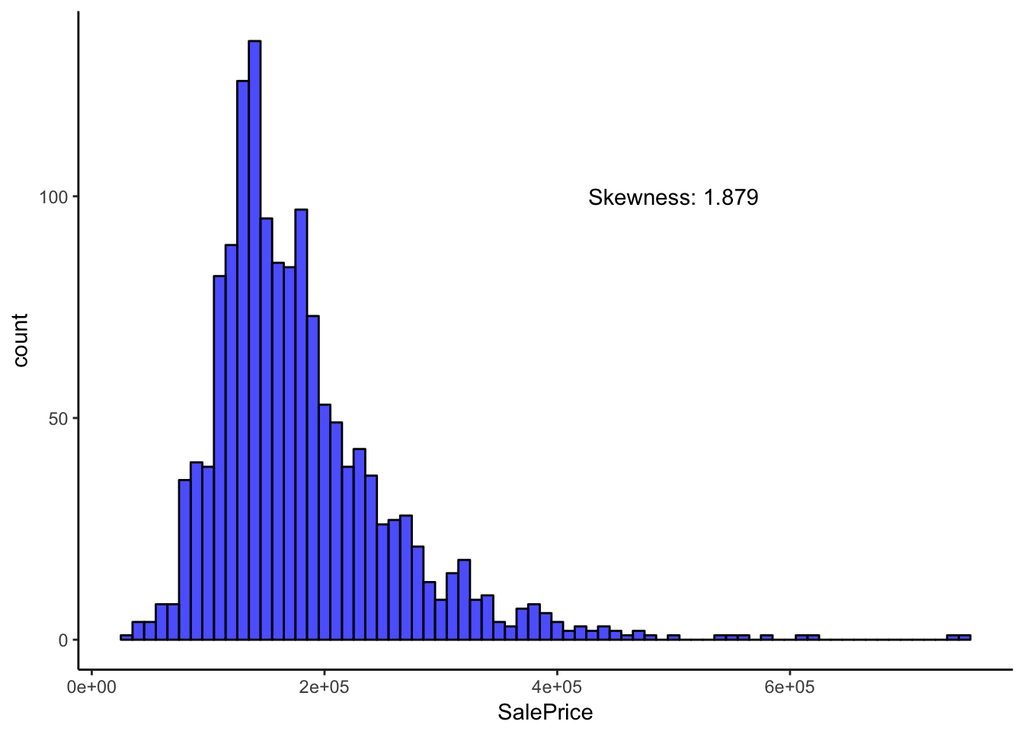

```r
ggplot(train, aes(x = SalePrice)) +
  geom_histogram(fill = "blue", col = "black", alpha = 0.7, binwidth = 10000) +
  annotate(geom="text", x=500000, y=100,
           label=paste("Skewness:", round(skewness(train$SalePrice), 4)))
```

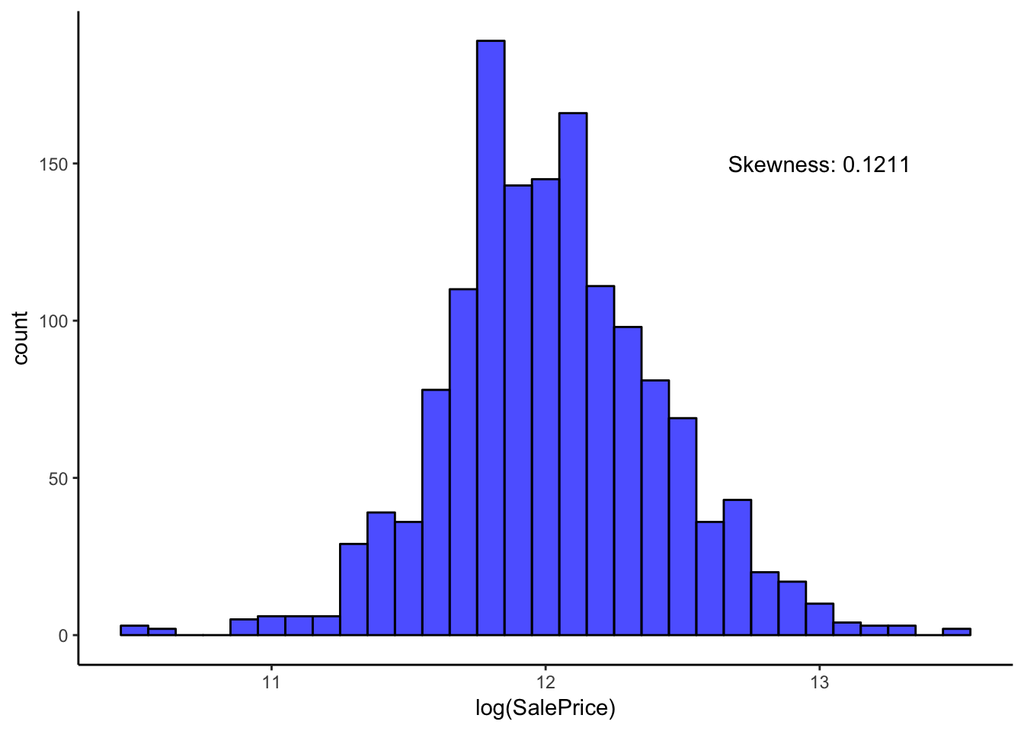

```r
ggplot(train, aes(x = log(SalePrice))) +
  geom_histogram(fill = "blue", col = "black", alpha = 0.7, binwidth = 0.1) +
  annotate(geom="text", x=13, y=150,
           label=paste("Skewness:", round(skewness(log(train$SalePrice)), 4)))
```

Two additional variables, HouseAge and Remodeled, were created. HouseAge is the difference between YearBuilt and YrSold. This show how old or new the house was at the time of sale. The distribution of this variable is shown in the histogram below. It is somewhat right-skewed and looks bimodal. Remodeled is a binary variable to show if the house has been remodeled since it was built.

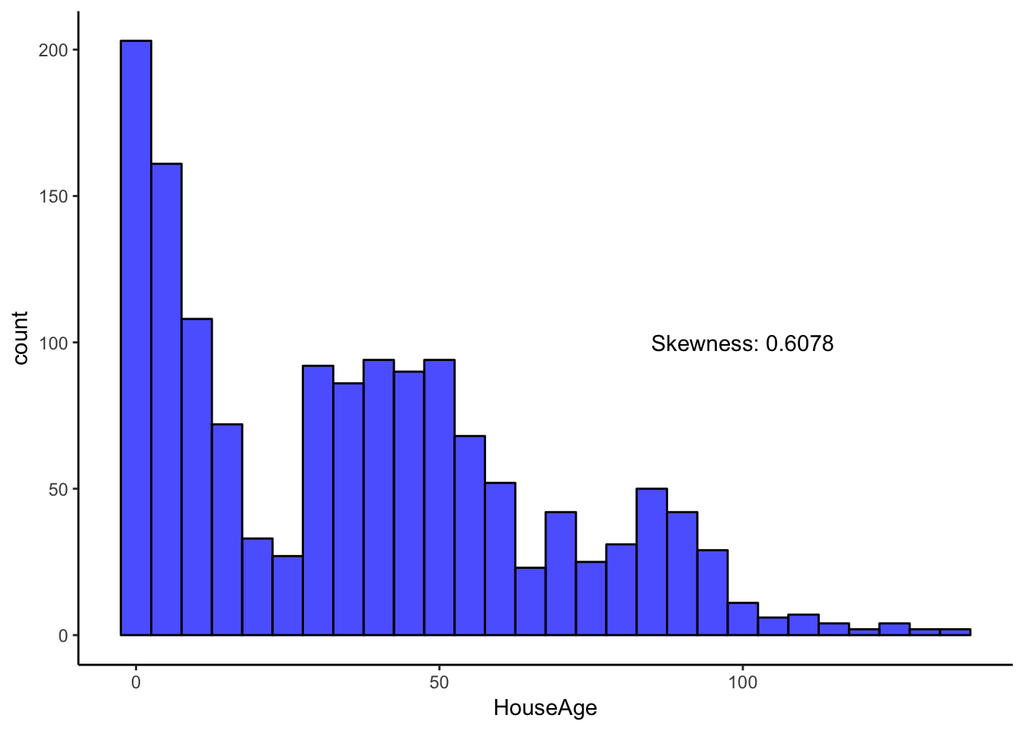

```r
train$HouseAge = train$YrSold - train$YearBuilt
train$Remodeled = ifelse(train$YearRemodAdd == train$YearBuilt, "Yes", "No")
train <- train %>% select(-YrSold, -YearBuilt, -YearRemodAdd)
ggplot(train, aes(x = HouseAge)) +
  geom_histogram(fill = "blue", col = "black", alpha = 0.7, binwidth = 5) +
  annotate(geom="text", x=100, y=100,
           label=paste("Skewness:", round(skewness(train$HouseAge), 4)))
```

Next, the relationship between SalePrice and selected numeric variables was investigated. A correlation heatmap is plotted below using the corrplot package. It does highlight some relationships between numeric variables, particularly those that are positively correlated with SalePrice. Among these include OverallQual, TotalBsmtSF, GrLivArea, GarageArea, and GarageCars. GArageArea and GarageCars are highly correlated with one another, which makes sense because the larger the area, the more cars can fit in the garage. The new variable HouseAge is actually negatively correlated with SalePrice, suggesting that older houses tend to have lower sale price. These variables were then investigated in more detail using the pairplots. The plots do hightlight that there are potential outliers in the data, particularly in the GrLivArea plots. This will be addressed later on using residuals from the model predictions.

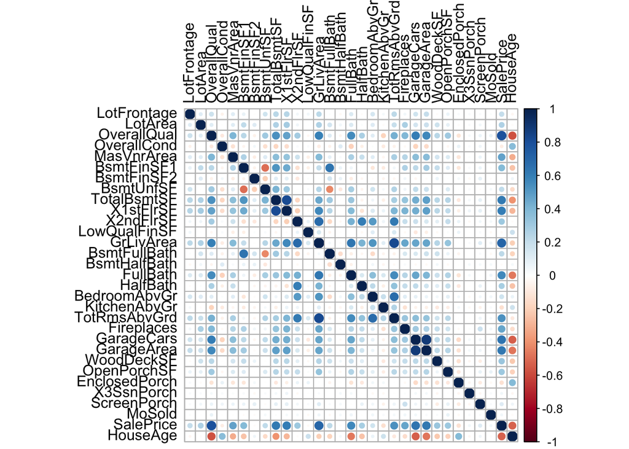

```r
train %>% select_if(is.numeric) %>% select(-Id) %>% cor() %>% corrplot(tl.col = "black")
```

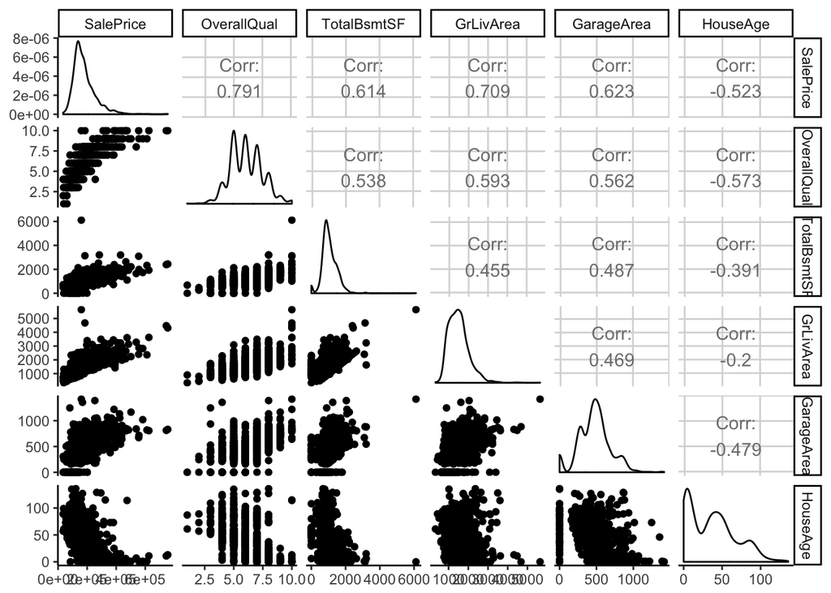

```r
train %>% select(SalePrice, OverallQual, TotalBsmtSF, GrLivArea, GarageArea, HouseAge) %>%
  ggpairs()
```

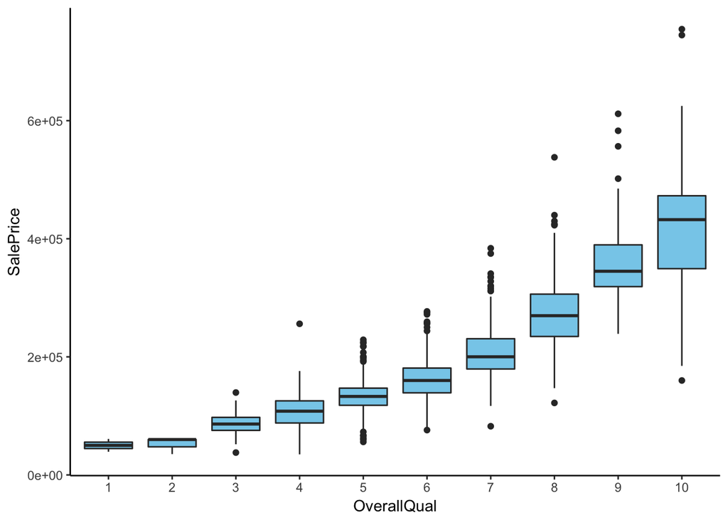

```r
ggplot(train, aes(x = factor(OverallQual), y = SalePrice)) +
  geom_boxplot(fill = "skyblue") + labs(x = "OverallQual") + theme(legend.position = "none")
```

Now, selected the categorical variables and their relationship with sale price will be explored. First, the sale price for houses in different neighborhoods is compared. The most expensive neighborhood by median house price is Northridge Heights, followed by Northridge and Stone Brook, while the cheapest neighborhood is Meadow Village.

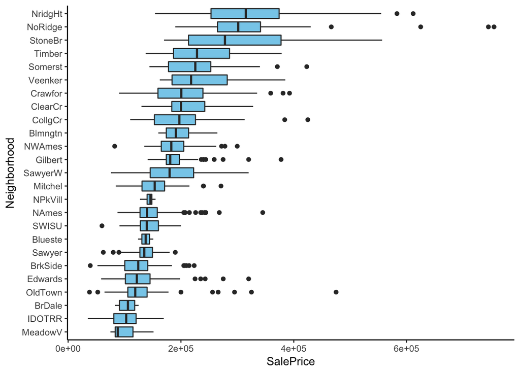

```r
ggplot(train, aes(x = reorder(Neighborhood, SalePrice, median, order = TRUE), y = SalePrice)) +
  geom_boxplot(fill = "skyblue") + xlab("Neighborhood") + coord_flip()
```

The new variable, Remodeled, showed that around 52% of houses in the training set have been remodeled. A boxplot of the sale price is shown below. there is only a slight difference in the median sale price between houses that have been remodeled and houses that have not. There are a large number of possible outliers here, although they are quite evenly spread between the categories.

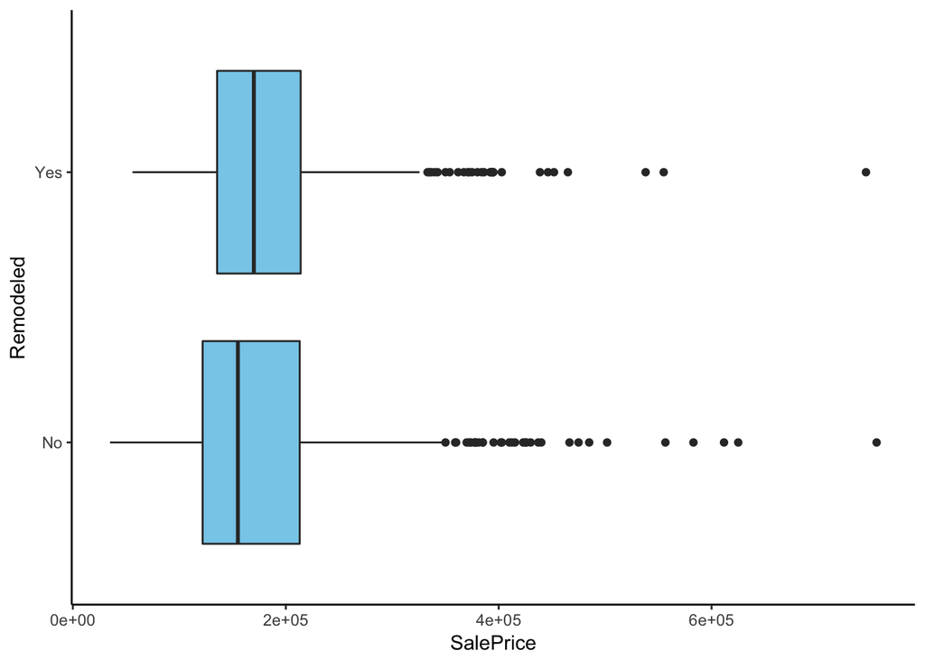

```r
ggplot(train, aes(x = Remodeled, y = SalePrice)) + geom_boxplot(fill = "skyblue") + coord_flip()
```

Next, looking at the zoning classification of the houses, the boxplot shows that a large number of observations are in low density residential zones. Floating village residential zones have the highest median sale price. There are also a large number of expensive houses in the low density residential zone, some of them may be outliers that could affect the model. This will be identified using residual plots later on.

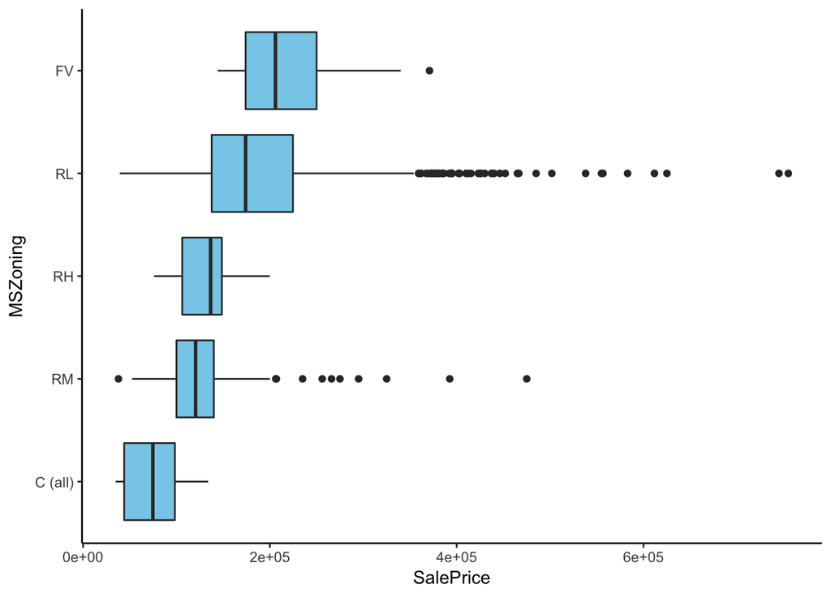

```r
ggplot(train, aes(x = reorder(MSZoning, SalePrice, median, order = TRUE), y = SalePrice)) +
  geom_boxplot(fill = "skyblue") + xlab("MSZoning") + coord_flip()
```

Another interesting boxplot is that of sale price for different types of house foundation. As shown by the boxplot, houses with poured concrete foundation tend to be more expensive compared to houses with other types of foundation.

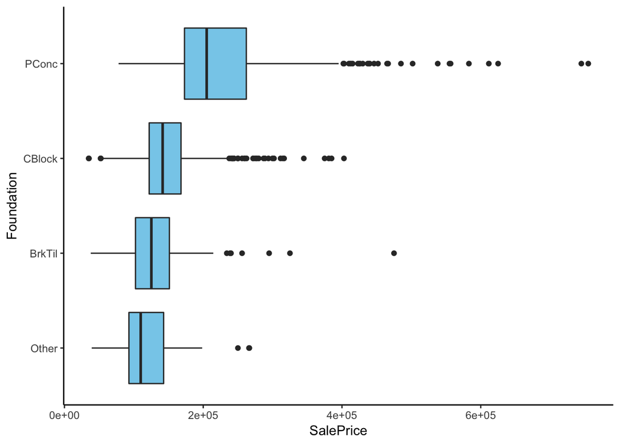

```r
ggplot(train, aes(x = reorder(Foundation, SalePrice, median, order = TRUE), y = SalePrice)) +
  geom_boxplot(fill = "skyblue") + xlab("Foundation") + coord_flip()
```

Other categorical variables can be explored in a similar way. I will not go through all of them in this kernel as it would take quite a bit of time and space. Other categorical variables of interest include those that measure quality and condition of various aspects of the house, LotConfig, LandContour, HouseStyle, Electrical, Functional, and Condition1.

```r
takeLog <- c("SalePrice", "LotArea", "X1stFlrSF", "GrLivArea")
takeLog1p <- c("X2ndFlrSF", "LowQualFinSF", "WoodDeckSF", "OpenPorchSF", "EnclosedPorch",
               "X3SsnPorch", "ScreenPorch")
takeSqrt <- c("LotFrontage", "BsmtFinSF1", "BsmtFinSF2", "BsmtUnfSF", "TotalBsmtSF", "HouseAge")
train[takeLog] <- log(train[takeLog])
train[takeLog1p] <- log1p(train[takeLog1p])
train[takeSqrt] <- sqrt(train[takeSqrt])
factorVar <- train %>% select_if(is.character) %>% colnames()
train[factorVar] <- lapply(train[factorVar], factor)
set.seed(42)
# split by neighborhood to ensure consistency between sets
spl <- sample.split(train$Neighborhood, SplitRatio = 0.5)
X_train <- train[spl,] %>% select(-Id, -SalePrice)
y_train <- train[spl,which(colnames(train) == "SalePrice")]
X_val <- train[!spl,] %>% select(-Id, -SalePrice)
y_val <- train[!spl,which(colnames(train) == "SalePrice")]
```

```r
set.seed(42)
rf_model <- randomForest(X_train, y_train, importance = TRUE)
```

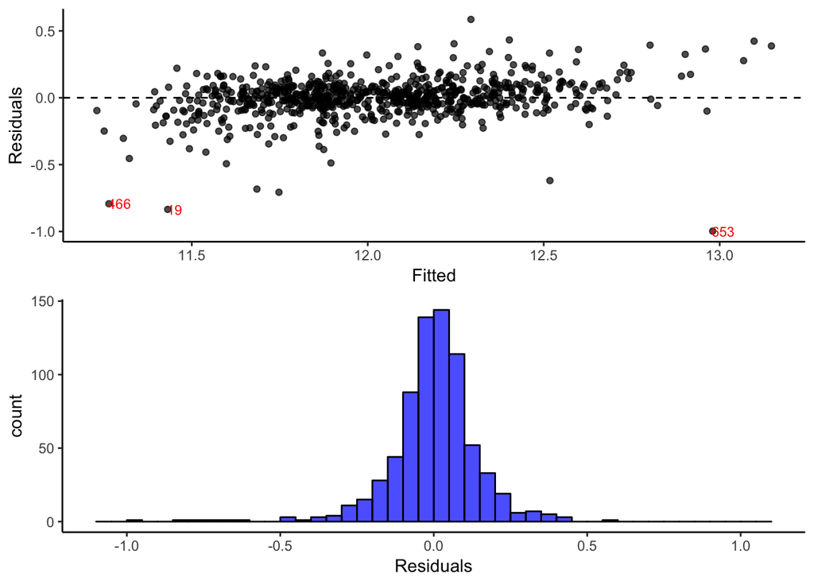

```r
train_predictions <- as_data_frame(cbind("Actual" = y_train,"Fitted" = rf_model$predicted))
train_predictions <- train_predictions %>% mutate(Residuals = Actual - Fitted)
train_resid_plot <- ggplot(train_predictions, aes(x = Fitted, y = Residuals)) +
  geom_point(alpha = 0.7) + geom_hline(aes(yintercept = 0), size = 0.5, linetype = "dashed") +
  annotate(x = train_predictions$Fitted[653] + 0.03, y = train_predictions$Residuals[653],
           geom = "text", label = "653", color = "red", size = 3) +
  annotate(x = train_predictions$Fitted[19] + 0.02, y = train_predictions$Residuals[19],
           geom = "text", label = "19", color = "red", size = 3) +
  annotate(x = train_predictions$Fitted[466] + 0.03, y = train_predictions$Residuals[466],
           geom = "text", label = "466", color = "red", size = 3)
train_resid_hist <- ggplot(train_predictions, aes(x = Residuals)) +
  geom_histogram(color= "black", fill = "blue", alpha = 0.7, breaks = seq(-1.1,1.1,0.05))
ggarrange(train_resid_plot, train_resid_hist, ncol = 1, nrow = 2)
```

```r
val_prediction <- predict(rf_model, newdata = X_val)
print(paste("Training set RMSE:",
            round(sqrt(sum(train_predictions$Residuals^2)/nrow(train_predictions)), 5)))
```

```
## [1] "Training set RMSE: 0.14521"
```

```r
print(paste("Validation set RMSE:",
            round(sqrt(sum((y_val - val_prediction)^2)/length(y_val)), 5)))
```

```
## [1] "Validation set RMSE: 0.14273"
```

```r
test$HouseAge = test$YrSold - test$YearBuilt
test$Remodeled = ifelse(test$YearRemodAdd == test$YearBuilt, "Yes", "No")
test <- test %>% select(-YrSold, -YearBuilt, -YearRemodAdd)
test$HouseAge[which(test$HouseAge < 0)] <- 0 # one house hasd an age of -1, replace with 0
takeLog <- c("LotArea", "X1stFlrSF", "GrLivArea")
takeLog1p <- c("X2ndFlrSF", "LowQualFinSF", "WoodDeckSF", "OpenPorchSF", "EnclosedPorch",
               "X3SsnPorch", "ScreenPorch")
takeSqrt <- c("LotFrontage", "BsmtFinSF1", "BsmtFinSF2", "BsmtUnfSF", "TotalBsmtSF", "HouseAge")
test[takeLog] <- log(test[takeLog])
test[takeLog1p] <- log1p(test[takeLog1p])
test[takeSqrt] <- sqrt(test[takeSqrt])
test[factorVar] <- lapply(test[factorVar], factor)
```

```r
test_prediction <- predict(rf_model, test[,-1])
submission <- cbind("Id" = test$Id, "SalePrice" = exp(test_prediction))
write.csv(submission, "RF_submission.csv", row.names = FALSE)
```